# Oyster Growth

Katie Lankowicz

2025-07-25

## Background

We are interested in testing for significant differences in oyster growth and condition between biofouled and clean bags.

We’ll use Index 3 for OCI, which is calculated as 100*dry meat weight (in grams) divided by dry shell weight (in grams).

## Oyster condition index over time

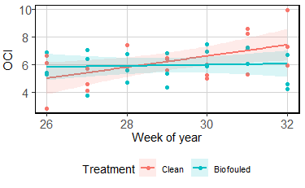

```r
# Load data
oci <- read.csv(here("QBC_Intern_Projects/2025/Oyster_Growth/OCI_Data.csv"))
# Remove spaces after your Clean label
oci$Condition[oci$Condition == 'Clean '] <- 'Clean'

# Clean data
oci <- oci %>%
  # Reformat date
  mutate(date = as.Date(Date, format='%m/%d/%Y')) %>%
  # Add variable for week
  mutate(week = isoweek(date)) %>%
  # Rename columns
  rename(condition = Condition,
         len = Length..mm.,
         wid = Width..mm.,
         i3 = Index.3) %>%
  # Change condition to a factor
  mutate(condition = factor(condition,
                            levels=c('Clean',
                                     'Biofouled'))) %>%
  # Select pertinent variables
  dplyr::select(date, week, condition,
                len, wid, i3)

# Add better ID variable
oci$ID <- seq(1, nrow(oci), 1)

# Find mean weekly values (across all 3 oysters sampled per week)
m.oci <- oci %>%
  # Group by week and year
  group_by(condition, week) %>%
  # Calcualte means
  summarise(i3 = mean(i3))

# Plot summer weekly average condition index
ggplot(data=oci) +
  # Point data, color
  geom_point(aes(x=week, y=i3, col=condition, group=condition)) +
  # Smoothed values to show overall trends
  geom_smooth(aes(x=week, y=i3, col=condition, fill=condition,
                  group=condition),
              # Make standard error ribbon more transparent
              alpha=0.15,
              # Adjust method and formula (smooth using GAM)
              #formula = y ~ s(x, k = 3, bs = "tp"),
              method='lm'
              ) +
  # Change axis and color labels
  labs(x='Week of year',
       y='OCI',
       col='Treatment', fill='Treatment')
```

## OCI by treatment

Next, we’ll run a test to determine if overall (not looking at weekly data, just total summer data) OCI is significantly different between the two treatments. Since we are comparing the means of two independent groups, we should use something like a t-test. We can start by using a boxplot or histogram to check the distribution of our data within each group.

We know that OCI changes over time, but we can assume that the proximity of our experimental oysters would mean that they experience incredibly similar environmental conditions (food, light, temperature, salinity) which we expect would affect OCI. Therefore, we will not include any covariates in this test. We can do that later to dig deeper into the results. Here, we just want to see if there is an overall difference in OCI.

The null hypothesis of our statistical test (Mann-Whitney-U) is that there is no difference in OCI betweent the clean and biofouled treatments. We assess this test at a confidence level of 95%, meaning the threshold for a significant p-value is 0.05.

For yourself, determine what we can conclude from the outcome of this test.

```r
# Number of samples per condition
table(oci$condition)
```

```
    Clean Biofouled
       21        21
```

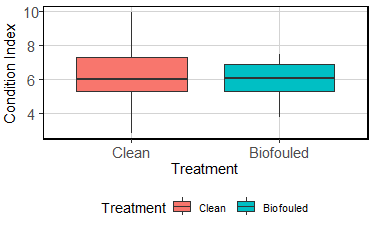

```r
# Boxplot
ggplot(data=oci) +
  geom_boxplot(aes(x=condition, y=i3, fill=condition)) +
  labs(x="Treatment", y="Condition Index", fill="Treatment")
```

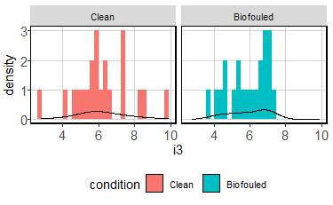

```r
# Histogram
ggplot(data=oci) +
  geom_histogram(aes(x=i3, fill=condition)) +
  # Add line visualizing cumulative distribution of values
  # If this is a bell curve we're great. If not, we have evidence of non-normality
  geom_density(aes(x=i3)) +
  facet_wrap(vars(condition))
```

```r
# Check for extreme outliers
oci %>%
  # Check for outliers
  rstatix::identify_outliers(i3) %>%
  # Keep only extreme outliers
  filter(is.extreme == TRUE) %>%
  # Convert back to dataframe; if extreme outliers don't exist, the dataframe will have 0 rows of observations.
  as.data.frame()
```

| date | week | condition | len | wid | i3 | ID | is.outlier | is.extreme |
| --- | --- | --- | --- | --- | --- | --- | --- | --- |

```r
# No extreme outliers found, keep all data

# Statistical test
wilcox.test(formula = i3 ~ condition,
            data=oci,
            alternative='two.sided',
            mu=0,
            conf.level=0.95,
            conf.int=T,
            order=c('Clean', 'Biofouled'))
```

```
    Wilcoxon rank sum exact test

data:  i3 by condition
W = 236, p-value = 0.7088
alternative hypothesis: true location shift is not equal to 0
95 percent confidence interval:
 -0.7369955  1.0924370
sample estimates:
difference in location
             0.2241279
```

## Oyster length

We have also tracked the sizes of labeled oysters over the summer. Let’s start by visualizing changes in length and width.

Overall, we see the oysters getting longer over the course of the summer. There is some weirdness to explain, though. We know an oyster died in the clean bag, that’s fine. But we also see some weeks where oysters get conspicuously shorter. Think about why that might have happened; it will be an important part of the discussion.

Also look at how the variance in oyster size is similar between biofouled and clean oysters in our first week (we did attempt to pick oysters of a simlar size), but the achieved size by the end of the summer is super variable in the biofouled bag. We should expect growth in the biofouled bag to be very variable. COnversely, the clean bag oysters achieved a similar size range by the end of the summer, so their growth should be similar across individuals.

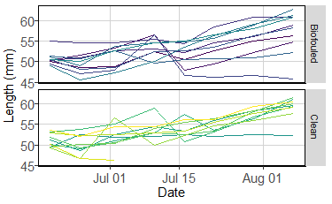

```r
# Load data
oyster <- read.csv(here("QBC_Intern_Projects/2025/Oyster_Growth/Oyster_Data.csv"))

# Adjust column names
colnames(oyster) <- str_to_lower(colnames(oyster))

# Clean data
oyster <- oyster %>%
  # Keep only pertinent varables
  dplyr::select(date, condition, bag, number, length, width) %>%
  # Format date
  mutate(date = as.POSIXct(date, format = "%m/%d/%Y")) %>%
  # Add column for week
  mutate(week = isoweek(date)) %>%
  # Format length and width
  mutate(length = as.numeric(length),
         width = as.numeric(width)) %>%
  # Change oyster ID number to a factor
  mutate(number = factor(paste0(condition, '_', number)))

# Plot changes in length per each oyster
ggplot(data=oyster)+
  geom_line(aes(x=date, y=length, color=as.factor(number)))+
  # Change color scale
  scale_color_viridis_d() +
  # Group by treatment
  facet_grid(vars(condition))+
  # Remove legend
  theme(legend.position = "n") +
  labs(y='Length (mm)', x='Date')
```

## Modeling weekly growth

We will now attempt to model growth as a linear function of time. We would normally not assume growth has a linear form, but we sample over such a short period that we are unlikely to see the true shape of oyster growth over its lifetime (which is probably more of a logistic function).

The result is super interesting. In each treatment, 3-4 oysters have either negative growth (or mortality) or week is not a significant perdictor of growth (weird, since there should be obvious autocorrelation where the size of an oyster in a week affects its size in the next week). We remove them from our interpretation (make them have gray lines to visualize this). Also note how the clean oysters have very similar trajectories of growth. The biofouled oysters have more variability in slope.

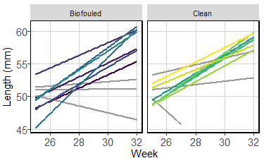

```r
# Model the growth of each labeled oyster as a linear function of week
oyster.growth <- oyster %>%
  group_by(condition, number) %>%
  # Keep slope of line (growth)
  # And keep significance of model (significance)
  summarise(growth = coefficients(lm(length ~ week))[2],
            significance =
              coefficients(summary(lm(length ~ week)))[8]) %>%
  # Reformat to data frame
  as.data.frame()

# Hightlight instances where growth is negative
# Negative growth indicates some external action unrelated to treatment
oyster.growth$dir <- 'Positive'
oyster.growth$dir[oyster.growth$growth <0] <- 'Negative'

# Highlight times when week is a significant predictor
oyster.growth$sig <- 'No'
oyster.growth$sig[oyster.growth$significance <=0.05] <- 'Yes'

# Add this information back to oyster dataframe
oyster <- merge(oyster, oyster.growth,
                by=c("condition", "number"))

# Visualize growth
# When growth is negative or week is not a significant predictor,
# make the line gray
ggplot() +

  geom_smooth(data=oyster[oyster$sig == 'No' |
                   oyster$dir == 'Negative',],
              aes(x=week, y=length,
                  group=number),
              method='lm',
              col='gray60',
              se=F,
              alpha=0.2) +

  geom_smooth(data=oyster[oyster$sig == 'Yes' &
                   oyster$dir == 'Positive',],
              aes(x=week, y=length,
                  group=number, col=number),
              method='lm',
              se=F,
              alpha=0.2) +

  scale_color_viridis_d() +
  facet_wrap(vars(condition)) +
  labs(x='Week', y='Length (mm)')+
  theme(legend.position = 'n')
```

## Testing for differences in growth

Same as with OCI, we will test if there is a significant difference in summer growth rate between the treatments. We will filter the data so we’re only looking at oysters with positive growth and where week is a significant predictor of length.

For yourself, interpret the outcome of this test.

```r
# Number of samples per condition
table(oyster.growth$condition[
  oyster.growth$dir == 'Positive' &
  oyster.growth$sig == 'Yes'
])
```

```
Biofouled     Clean
        7         7
```

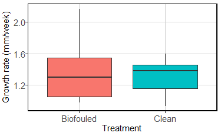

```r
# Boxplot
ggplot(data=oyster.growth[
  oyster.growth$dir == 'Positive' &
  oyster.growth$sig == 'Yes',
]) +
  geom_boxplot(aes(x=condition, y=growth, fill=condition)) +
    labs(x="Treatment", y="Growth rate (mm/week)",
       fill=NULL) +
  theme(legend.position = 'n')
```

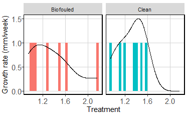

```r
# Histogram
ggplot(data=oyster.growth[
  oyster.growth$dir == 'Positive' &
  oyster.growth$sig == 'Yes',
]) +
  geom_histogram(aes(x=growth, fill=condition)) +
  # Add line visualizing cumulative distribution of values
  # If this is a bell curve we're great. If not, we have evidence of non-normality
  geom_density(aes(x=growth)) +
  facet_wrap(vars(condition)) +
  labs(x="Treatment", y="Growth rate (mm/week)",
       fill=NULL) +
  theme(legend.position = 'n')
```

```r
# Check for extreme outliers
oyster.growth[
  oyster.growth$dir == 'Positive' &
  oyster.growth$sig == 'Yes',
] %>%
  # Check for outliers
  rstatix::identify_outliers(growth) %>%
  # Keep only extreme outliers
  filter(is.extreme == TRUE) %>%
  # Convert back to dataframe; if extreme outliers don't exist, the dataframe will have 0 rows of observations.
  as.data.frame()
```

| condition | number | growth | significance | dir | sig | is.outlier | is.extreme |
| --- | --- | --- | --- | --- | --- | --- | --- |

```r
# No extreme outliers found, keep all data

wilcox.test(formula = growth ~ condition,
            data=oyster.growth[oyster.growth$dir=='Positive' &
                               oyster.growth$sig == 'Yes',],
            alternative='two.sided',
            mu=0,
            conf.level=0.95,
            conf.int=T,
            order=c('Clean', 'Biofouled'))
```

```
    Wilcoxon rank sum exact test

data:  growth by condition
W = 25, p-value = 1
alternative hypothesis: true location shift is not equal to 0
95 percent confidence interval:
 -0.3997619  0.5419048
sample estimates:
difference in location
            0.02345238
```

## Difference in variability of growth between treatments

It looks like the biofouled oysters have a much high variability in individual growth rates, which causes the range of final oyster lengths to be much larger in this group as compared to the clean oysters. Let’s test this using the Levene test. The null hypothesis of this test is that there is no difference in variance across groups. The alternative is that there is a difference in variance across groups.

First, we will confirm that the variance in oyster lengths in week 1 between the biofouled and clean treatments is not significantly different. This confirms that we successfully selected oysters of a similar size. Our p-value is 0.38, which indicates we do not have enough evidence to reject the null hypothesis of no difference in variance. Good!

Finally, we will test for a difference in variance in our calculated growth rates between the clean and biofouled oysters. This test has limited statistical power to detect differences because there are only 7 oysters per treatment level that had growth rates. The test indicates that there is not enough evidence to reject the null hypothesis of no difference.

```r
# Highlight first and last weeks
oyster$endpoint[oyster$date == min(oyster$date)] <- 'First'
oyster$endpoint[oyster$date == max(oyster$date)] <- 'Last'

# Test for difference in length variation between treatments in week 1
rstatix::levene_test(data=oyster[oyster$endpoint == 'First',],
                     formula = length ~ as.factor(condition))
```

| df1 | df2 | statistic | p |
| --- | --- | --- | --- |
| 1 | 18 | 0.7990617 | 0.3831708 |

```r
# For biofouled treatment, test for difference in length variation in week 1 vs last week
rstatix::levene_test(data=oyster[oyster$condition == 'Biofouled' &
                                 !is.na(oyster$endpoint),],
                     formula = length ~ as.factor(endpoint))
```

| df1 | df2 | statistic | p |
| --- | --- | --- | --- |
| 1 | 18 | 4.987896 | 0.03845776 |

```r
# For clean treatment, test for difference in length variation in week 1 vs last week
rstatix::levene_test(data=oyster[oyster$condition == 'Clean' &
                                 !is.na(oyster$endpoint),],
                     formula = length ~ as.factor(endpoint))
```

| df1 | df2 | statistic | p |
| --- | --- | --- | --- |
| 1 | 17 | 0.1019081 | 0.753441 |

```r
# Test for difference in growth rate variation between treatments
rstatix::levene_test(data=oyster.growth[oyster.growth$dir == "Positive" & oyster.growth$sig == "Yes",],
                     formula = growth ~ as.factor(condition))
```

| df1 | df2 | statistic | p |
| --- | --- | --- | --- |
| 1 | 12 | 1.248004 | 0.2858024 |

```r
NA
```

## Explanatory variables

Now, the fun part. Let’s see if we can figure out if there are any environmental covariates that significantly predict OCI or growth over the summer. We start by loading, cleaning, and visualizing potential environmental covariates.

### HOBO temperature logs

Temperature within the clean and biofouled bags is very similar, but there are some minute differences that hint at small-scale spatial variability between what’s going on in the two cages.

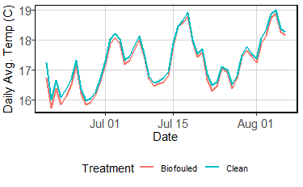

```r
# HOBO data
foul.hobo <- read_excel(here('QBC_Intern_Projects/2025/Oyster_Growth/dirty_hobo.xlsx'))
clean.hobo <- read_excel(here('QBC_Intern_Projects/2025/Oyster_Growth/clean_hobo.xlsx'))

# Clean Biofoul bag data
foul.hobo <- foul.hobo %>%
  # Rename date, temperature, and light columns to not contain spaces
  rename(Date = `Date-Time (EDT)`,
         Temperature = `Temperature , °C`,
         Light = `Light , lux`) %>%
  # Remove instances where data were not recorded
  filter(!is.na(Temperature) &
           !is.na(Light)) %>%
  # Format date variable so R understands it as a date
  mutate(Date = as.POSIXct(Date,
                           format='%Y-%m-%d %H:%M:%S',
                           tz='America/New_York')) %>%
  # It keeps defaulting to UTC, so add 4 hours to get Eastern Time
  mutate(Date = Date + hours(4)) %>%
  # Strip to begin data when logger is in the water
  filter(Date >= as.POSIXct('2025-06-19 15:00:00')) %>%
  # Add name of Condition
  mutate(Condition = 'Biofouled') %>%
  # Select only the columns that are useful to us
  dplyr::select(Condition, Date, Temperature) %>%
  # Format as data frame
  as.data.frame()

# Clean Clean bag data
clean.hobo <- clean.hobo %>%
  # Rename date, temperature, and light columns to not contain spaces
  rename(Date = `Date-Time (EDT)`,
         Temperature = `Temperature , °C`,
         Light = `Light , lux`) %>%
  # Remove instances where data were not recorded
  filter(!is.na(Temperature) &
           !is.na(Light)) %>%
  # Format date variable so R understands it as a date
  mutate(Date = as.POSIXct(Date,
                           format='%Y-%m-%d %H:%M:%S',
                           tz='America/New_York')) %>%
  # It keeps defaulting to UTC, so add 4 hours to get Eastern Time
  mutate(Date = Date + hours(4)) %>%
  filter(Date >= as.POSIXct('2025-06-19 15:00:00')) %>%
  # Add name of Condition
  mutate(Condition = 'Clean') %>%
  # Select only the columns that are useful to us
  dplyr::select(Condition, Date, Temperature) %>%
  # Format as data frame
  as.data.frame()

# Combine
hobo <- rbind(clean.hobo, foul.hobo)
hobo <- hobo %>%
  rename(timestamp = Date) %>%
  rename(condition = Condition)

# Daily average values
hobo.daily <- hobo %>%
  mutate(date = as.Date(timestamp)) %>%
  group_by(date, condition) %>%
  summarise(meanT = mean(Temperature, na.rm=T))

# Plot
ggplot(hobo.daily) +
  geom_line(aes(x=date, y=meanT, col=condition), lwd=1) +
  labs(x='Date', y='Daily Avg. Temp (C)',
       col='Treatment')
```

### Bowdoin Buoy data

The Bowdoin Buoy gives a good description of seasonal-scale changes in environmental conditions. We see things getting warmer and saltier as the summer progresses. We also see a decline in colored dissolved organic material (CDOM), which is linked to riverine input. We would expect high riverine input and therefore high CDOM with spring thaws and rain events. Fluorescence is a measure of photosynthetic material in the water, and may reflect both riverine input and the thermal stratification of the surface layer leading to high phytoplankton abundance.

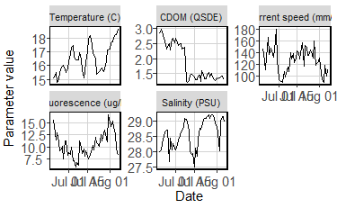

### Dogs Head Weather Station

Rain events have been mentioned a few times. The personal weather station across from the Dogs Head lease will be a good data source for rain input in our area. We know rain impacts the oysters in a negative way by introducing a surface lens of fresh water. The reduction in temperature and salinity associated with rain should negatively impact oyster body condition and growth.

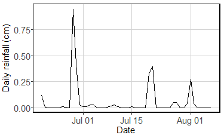

### Merge all data with length

We should attempt to visualize the relationships between all these environmental variables (from the HOBOs, Bowdoin Buoy, and weather station) and weekly oyster length.

Most of these variables don’t have obvious or linear relationships to weekly oyster length. Keep in mind that both weekly environmental conditions and weekly oyster length have significant autocorrelation– they’re repeated measures that are partially dependent upon their previous state. And some of the environmental conditions should be considered correlated (temperature is related to salinity, because cooler waters are typically high tides that bring more saline water into our area). However, it looks like the temperature (hobo.temp and buoy.temp), salinity, and fluorescence variables have positive correlations to oyster length.

[figure not shown]

```r
# Assume we collected oysters at 7 each day
oyster$timestamp <- paste0(oyster$date, " 07:00:00")
oyster$timestamp <- as.POSIXct(oyster$timestamp, tz="America/New_York")
oyster$event <- as.numeric(as.factor(oyster$date))

# Merge hobo and oyster lenght data
m.oyst <- merge(oyster, hobo, by=c('condition', 'timestamp'),
                all=T)

# Merge Bowdoin Buoy and oyster data
m.oyst <- merge(m.oyst, buoy, by=c('timestamp'), all=T)

# Merge AmbientWeather and oyster data
m.oyst <- merge(m.oyst, aw, by=c('timestamp'), all=T)

# Cut stuff from after sampling
m.oyst <- m.oyst[m.oyst$timestamp <=
                   as.POSIXct('2025-08-07 07:00:00'),]

# Rolling upward, fill "event" column with previous known value
m.oyst$event <- zoo::na.locf(m.oyst$event, fromLast = T)

# Average conditions in bags between sampling
m.oyst <- m.oyst %>%
  filter(event > 1) %>%
  group_by(event, condition) %>%
  summarise(hobo.temp = mean(Temperature, na.rm=T),

            cdom = mean(cdom, na.rm=T),
            current.spd = mean(current.spd, na.rm=T),
            fluor = mean(fluor, na.rm=T),
            sal= mean(sal, na.rm=T),
            buoy.temp = mean(buoy.temp, na.rm=T),

            Daily.Rain = sum(Daily.Rain, na.rm=T)
            ) %>%
  filter(!is.na(condition)) %>%
  as.data.frame()
# Re-merge temp and oyster data
oyster <- left_join(oyster,
                    m.oyst,
                    by=c('event', 'condition'))

# Pivot for easier plotting
oyster.for.plotting <- oyster %>%
  filter(dir == 'Positive' & sig=='Yes') %>%
  dplyr::select(event, condition, length, width,
                hobo.temp, cdom, current.spd,
                fluor, sal, buoy.temp, Daily.Rain) %>%
  pivot_longer(cols=c('hobo.temp', 'cdom', 'current.spd',
                      'fluor', 'sal', 'buoy.temp',
                      'Daily.Rain'),
               names_to = 'environ',
               values_to = 'values')

varnames <- c('Buoy Temperature (C)', 'CDOM (QSDE)',
              'Current speed (mm/s)',
              'Daily Rain (cm)',
              'Fluorescence (ug/L)',
              'HOBO Temperature (C)',
              'Salinity (PSU)')
names(varnames) <- c('buoy.temp', 'cdom', 'current.spd',
                     'Daily.Rain',
                     'fluor', 'hobo.temp', 'sal')


# Plot weekly sizes vs all parameters
ggplot(oyster.for.plotting) +
    geom_point(aes(y=length, x=values, col=condition)) +
    facet_wrap(vars(environ), scales='free_x',
               labeller=labeller(environ = varnames)) +
  labs(y='Oyster length (mm)', x='Environmental Parameter',
       col='Treatment')
```

### Merge all data with OCI

We’ll repeat the process looking for relationships between OCI and the environmental variables. Since we take OCI from separate individuals each week, we don’t have to worry as much about autocorrelation in this signal. It still exists for the environmental variables, though.

[figure not shown]

```r
# Assume we collected oysters at noon each day
oci$timestamp <- paste0(oci$date, " 07:00:00")
oci$timestamp <- as.POSIXct(oci$timestamp)
oci$event <- as.numeric(as.factor(oci$date))

# Merge hobo and oyster lenght data
m.oyst <- merge(oci, hobo, by=c('condition', 'timestamp'),
                all=T)

# Merge Bowdoin Buoy and oyster data
m.oyst <- merge(m.oyst, buoy, by=c('timestamp'), all=T)

# Merge AmbientWeather and oyster data
m.oyst <- merge(m.oyst, aw, by=c('timestamp'), all=T)

# Cut stuff from after sampling
m.oyst <- m.oyst[m.oyst$timestamp <=
                   as.POSIXct('2025-07-30 07:00:00'),]

# Rolling upward, fill "event" column with previous known value
m.oyst$event <- zoo::na.locf(m.oyst$event, fromLast = T)

# Average conditions in bags between sampling
m.oyst <- m.oyst %>%
  filter(event > 1) %>%
  group_by(event, condition) %>%
  summarise(hobo.temp = mean(Temperature, na.rm=T),

            cdom = mean(cdom, na.rm=T),
            current.spd = mean(current.spd, na.rm=T),
            fluor = mean(fluor, na.rm=T),
            sal= mean(sal, na.rm=T),
            buoy.temp = mean(buoy.temp, na.rm=T),

            Daily.Rain = sum(Daily.Rain, na.rm=T)
            ) %>%
  filter(!is.na(condition)) %>%
  as.data.frame()
# Re-merge temp and oyster data
oci <- left_join(oci,
                    m.oyst,
                    by=c('event', 'condition'))

# Plot for funsies
oyster.for.plotting <- oci %>%
  dplyr::select(event, condition,
                hobo.temp, cdom, current.spd,
                fluor, sal, buoy.temp, Daily.Rain, i3) %>%
  pivot_longer(cols=c('hobo.temp', 'cdom', 'current.spd',
                      'fluor', 'sal', 'buoy.temp',
                      'Daily.Rain'),
               names_to = 'environ',
               values_to = 'values')

# Plot weekly sizes
ggplot(oyster.for.plotting) +
    geom_point(aes(y=i3, x=values, col=condition)) +
    facet_wrap(vars(environ), scales='free_x',
               labeller=labeller(environ = varnames)) +
  labs(y='Condition Index', x='Environmental Parameter',
       col='Treatment')
```

## Modeling OCI with environmental conditions

We will now do a slightly more complicated modeling process to see if there are variables that predict OCI. We won’t do this for length because of the noted autocorrelation issues.

The approach we use here is a generalized additive model. Similar to the multiple linear regressions we did earlier this summer, this modeling approach tests for the ability of each explanatory variable to predict the response variable. Response variable is Index 3. We will use hobo temperature, cdom, fluorescence, current speed, and daily rain as our environmental explanatory variables. We won’t use Bowdoin buoy temperature or salinity, because those are likely highly correlated to the hobo logger data and we don’t need to duplicate signals. We will split the hobo loggers by biofouled/ clean treatment. The loggers were right next to each other and should have similar signals, but there may be some super fine-spatial-scale variation that would impact OCI. We will also add in a term for week, with the expectation that the time elapsed over the study may have its own impact on OCI. Finally, we will have a factor term for treatment (condition), with the expectation that biofouled vs clean bags may impact OCI.

GAMS are structured so each explanatory variable is a smoother term. It does not assume a linear relationship between the explanatory and response variables, unlike linear regression. We specify smoother terms by using the s() function. Each smoother term is calculated as a thin plate spline (bs=‘tp’). Don’t worry too much about what this means. We also have to specify the number of knots (k=4), which tells the model how much “squiggle” we allow it to have. By squiggle, I mean how many points at which we allow for the model to have an inflection point that helps shape curviness of each smoother function. Here, we specify 4 knots because we only have 5 weeks of OCI data. We’ll talk more about how to pick the number of knots later.

```r
# Make a generalize additive model
g1 <- mgcv::gam(data=oci,
                formula = i3 ~
                  s(week, k=4, bs='tp') +
                  s(hobo.temp, k=4, by=condition, bs='tp') +
                  s(cdom, k=4, bs='tp') +
                  s(current.spd, k=4, bs='tp') +
                  s(fluor, k=4, bs='tp') +
                  s(Daily.Rain, k=4, bs='tp') +
                  condition,

                method = 'REML',
                select=T)

summary(g1)
```

```
Family: gaussian
Link function: identity

Formula:
i3 ~ s(week, k = 4, bs = "tp") + s(hobo.temp, k = 4, by = condition,
    bs = "tp") + s(cdom, k = 4, bs = "tp") + s(current.spd, k = 4,
    bs = "tp") + s(fluor, k = 4, bs = "tp") + s(Daily.Rain, k = 4,
    bs = "tp") + condition

Parametric coefficients:
                   Estimate Std. Error t value Pr(>|t|)
(Intercept)         6.10283    0.28557  21.371   <2e-16 ***
conditionBiofouled -0.01831    0.40385  -0.045    0.964
---
Signif. codes:  0 ‘***’ 0.001 ‘**’ 0.01 ‘*’ 0.05 ‘.’ 0.1 ‘ ’ 1

Approximate significance of smooth terms:
                                      edf Ref.df     F p-value
s(week)                         6.920e-01      3 0.749   0.059 .
s(hobo.temp):conditionClean     1.166e-05      3 0.000   0.612
s(hobo.temp):conditionBiofouled 4.856e-06      3 0.000   0.678
s(cdom)                         5.617e-06      3 0.000   0.754
s(current.spd)                  9.828e-06      3 0.000   0.516
s(fluor)                        9.258e-01      3 0.601   0.144
s(Daily.Rain)                   1.176e-05      3 0.000   0.326
---
Signif. codes:  0 ‘***’ 0.001 ‘**’ 0.01 ‘*’ 0.05 ‘.’ 0.1 ‘ ’ 1

R-sq.(adj) =  0.151   Deviance explained = 22.8%
-REML = 46.585  Scale est. = 1.2232    n = 30
```

[figure not shown]

```r
b <- mgcViz::getViz(g1)

print(plot(b, allTerms = T), pages=1)
```

None of these terms are significant (high p values in the summary() function). You can also see this visually in all the subplots. Each subplot describes how a specific variable will affect OCI if all other variables are held constant. The dotted lines are the 95% confidence envelope around the estimated relationship. Notice how most terms are flat lines, indicating no relationship between the explanatory and response variables.

The results of the GAM may change when the final OCI values are recorded on Monday.

Look at the final subplot: the collection of OCI values for biofouled oysters encompasses the estimated OCI value for clean oysters held in the same conditions. How would you interpret this? Do you think biofoul/ clean treatment has an impact on OCI?

## Discussion

Your discussion is going to take some effort to write. We have lots of things to discuss. You can think about three buckets of potential impact to the data.

1. Handling– what is our ability to accurately measure such small increments of growth? Are our calipers good enough? Is our calibration of the calipers good enough? Are the oysters being chipped either by us or by other crap in the bags? Are they chipping each other?
2. Time– Is this a long enough period to determine a response? Is this summer period the best time to see a response, or should we be focusing on the periods before/ after oysters are in their thermal optimum for growing?
3. Homogeneity of treatment– We know that the biofouled bags do not have the same diversity and concentration of biofouling organisms across the space of the bags. Some areas might have more intense biofouling, or organisms that have stronger competition for prey resources/ stronger ability to affect water flow. This means we cannot assume oysters in the biofouled treatment will have the same response to being in that bag.